# Modelo inferencial: beta-binomial misto com dispersão aleatória

Datanautas — Datathon Impacta.dev 2026

Autor

Equipe Datanautas

Data de Publicação

23 de outubro de 2026

## Sobre este notebook

Este notebook parte do arquivo original `data/raw/cursos_ano.parquet` e executa **toda a parte inferencial** do projeto:

1. preparação dos dados;
2. especificação, compilação e teste da verossimilhança;
3. ajuste do modelo adotado e do modelo de comparação;
4. diagnóstico por simulação;
5. Hessiana, intervalos de confiança e figuras;
6. comparação com os achados da exploração (`notebooks/01_EDA_trancamento.qmd`).

O texto explica cada passo e o código fica recolhido.

**Parâmetros de execução** (a partir da raiz do repositório):

```bash
nix develop -c quarto render notebooks/02_modelo_inferencial.qmd                      # reaproveita ajustes salvos
nix develop -c quarto render notebooks/02_modelo_inferencial.qmd -P reajustar:true    # refaz tudo do zero (horas)
nix develop -c quarto render notebooks/02_modelo_inferencial.qmd -P reserva:true      # inclui validação em anos reservados
```

Os ajustes por máxima verossimilhança levam de 20 a 40 minutos cada, e a Hessiana cerca de 12. Por padrão, o notebook **reaproveita** os modelos e a Hessiana já salvos em `outputs/modelo/variantes/filtrada/`, que foram produzidos por este mesmo código. A preparação dos dados, os testes, as simulações e todas as tabelas e figuras são sempre recalculados. Os resultados das simulações ficam em cache em `.cache/notebooks/` para acelerar renderizações repetidas.

**Mostrar código**

```r
suppressPackageStartupMessages({library(data.table); library(ggplot2); library(knitr)})
# Biblioteca do projeto: densidade truncada, momentos, simulador, matrizes de desenho
# e compilação do .cpp. Ao ser carregada, não ajusta nada.
source("scripts/modelo/variantes.R")
POP <- "filtrada"; B <- as.integer(params$simulacoes); REAJUSTAR <- isTRUE(params$reajustar)
NB_CACHE <- ".cache/notebooks"; dir.create(NB_CACHE, recursive = TRUE, showWarnings = FALSE)
br  <- function(x, d = 1) formatC(x, format = "f", digits = d, big.mark = ".", decimal.mark = ",")
pct <- function(x, d = 1) paste0(br(100 * x, d), "%")
tab <- function(x, ...) kable(x, format.args = list(big.mark = ".", decimal.mark = ","), ...)
# Cache simples em disco, invalidado quando a chave (hashes das entradas) muda.
em_cache <- function(nome, chave, expr) {
  f <- file.path(NB_CACHE, paste0(nome, ".rds"))
  if (file.exists(f)) { x <- readRDS(f); if (identical(x$chave, chave)) return(x$valor) }
  valor <- expr; saveRDS(list(chave = chave, valor = valor), f); valor
}
AZUL <- "#2a78d6"; LARANJA <- "#eb6834"
theme_set(theme_minimal(base_size = 12) + theme(plot.title.position = "plot", panel.grid.minor = element_blank()))
```

# 1 Preparação dos dados

A preparação lê o Parquet, confere as identidades contábeis, constrói a resposta e os perfis e calcula os contextos institucionais. Também marca um ano por curso como **reserva**, usada apenas na seção opcional de validação. O resultado é gravado em `data/processed/modelo.rds` (ignorado pelo Git), lido pelas funções da biblioteca.

**Mostrar código**

```r
d0 <- as.data.table(nanoparquet::read_parquet("data/raw/cursos_ano.parquet"))
contagens <- c("matriculas", "trancados", "desvinculados", "transferidos", "falecidos", "vinculos", paste0("mat_", PROFILES))
for (v in contagens) set(d0, j = v, value = as.numeric(d0[[v]]))
stopifnot(!anyDuplicated(d0[, .(co_curso, ano)]),
          all(d0$vinculos == d0$matriculas + d0$trancados + d0$desvinculados + d0$transferidos + d0$falecidos),
          all(d0$poucos_alunos == as.integer(d0$vinculos < 30)))
n_original <- nrow(d0)
d0 <- d0[matriculas > 0]
stopifnot(all(d0[modalidade == "EAD", mat_noturno] == 0))   # noturno é zero estrutural no EAD
# Fatores com as categorias de referência do modelo
for (v in CONTROLS) d0[[v]] <- relevel(factor(d0[[v]]), ref = REFERENCES[[v]])
# Perfis: proporção dos matriculados, em unidades de 10 pp (deficiência: 1 pp)
for (j in seq_along(PROP)) d0[[PROP[j]]] <- d0[[paste0("mat_", PROFILES[j])]] / d0$matriculas / SCALE[j]
d0[, `:=`(co_curso = factor(co_curso), co_ies = factor(co_ies))]
setorder(d0, co_curso, ano)
d0 <- d0[, unique(c("co_curso", "co_ies", CONTROLS, contagens, "presente_5_anos", "poucos_alunos", PROP)), with = FALSE]
d0[, linha_original := .I]
# Contextos da IES: médias dos perfis (anos com pesos iguais por curso, cursos com pesos iguais
# por IES), média de log(N), fração EAD e log do número de cursos; padronizados entre IES.
a <- d0[, c(lapply(.SD, mean), list(logN = mean(log(vinculos)), ead = mean(modalidade == "EAD"))), by = .(co_ies, co_curso), .SDcols = PROP]
ctx <- a[, c(lapply(.SD, mean), list(log_n_cursos = log(.N))), by = co_ies, .SDcols = c(PROP, "logN", "ead")]
setnames(ctx, c(PROP, "logN", "ead", "log_n_cursos"), CTX)
for (v in CTX) ctx[, (v) := (get(v) - mean(get(v))) / sd(get(v))]
for (v in CTX) d0[, (v) := ctx[[v]][match(co_ies, ctx$co_ies)]]
# Reserva: um ano sorteado por par IES/curso com pelo menos dois anos (só para a seção opcional)
set.seed(20261022L)
reservadas <- d0[, if (.N >= 2L) .(linha = sample(linha_original, 1L)) else .(linha = integer()), by = .(co_ies, co_curso)]$linha
d0[, validacao := linha_original %in% reservadas]
d0[, `:=`(eventos_resposta = desvinculados + trancados, demais_vinculos = vinculos - desvinculados - trancados)]
stopifnot(all(d0$eventos_resposta < d0$vinculos))           # matrículas > 0 implica Y < N
# Grava só se mudou: preserva o hash do arquivo usado na verificação dos modelos salvos.
if (!file.exists(BASE_PATH) || !isTRUE(all.equal(readRDS(BASE_PATH), d0, check.attributes = FALSE))) atomic_rds(d0, BASE_PATH)
d <- populacao(POP)                                          # aplica presente_5_anos == 1 e ≥ 30 vínculos
tab(data.table(Etapa = c("Base original", "Matrículas positivas", "População analisada"),
               `Curso-anos` = c(n_original, nrow(d0), nrow(d)),
               Cursos = c(NA, uniqueN(d0$co_curso), uniqueN(d$co_curso)),
               IES = c(NA, uniqueN(d0$co_ies), uniqueN(d$co_ies))))
```

| Etapa | Curso-anos | Cursos | IES |
| --- | --- | --- | --- |
| Base original | 220.686 | NA | NA |
| Matrículas positivas | 211.651 | 51.603 | 2.936 |
| População analisada | 152.484 | 32.953 | 2.128 |

**Resposta.** $Y$ = desvinculados + trancados; $N$ = vínculos. Como há pelo menos uma matrícula, nunca ocorre $Y = N$.

**População.** Cursos presentes nos cinco anos e curso-anos com 30 vínculos ou mais: os resultados valem para cursos estáveis e não muito pequenos. Os contextos institucionais são calculados antes do filtro, com todos os cursos da IES.

# 2 O modelo

Para o curso $i$ da instituição $j$ no ano $t$:

$$\begin{aligned}
Y_{it} \mid p_{it} &\sim \text{Binomial}(N_{it}, p_{it}) \ \text{condicionado a } Y_{it} < N_{it}, \qquad p_{it} \sim \text{Beta}(\mu_{it}, \phi_{it}),\\
\operatorname{logit}\mu_{it} &= \mathbf{x}_{it}^\top\boldsymbol\beta + u_j + u_i, \qquad u_j \sim N(0,\sigma^2_{\text{IES}}),\ u_i \sim N(0, \sigma^2_{\text{curso}}),\\
\log\phi_{it} &= \mathbf{z}_{it}^\top\boldsymbol\gamma + v_j + v_i, \qquad v_j \sim N(0,\tau^2_{\text{IES}}),\ v_i \sim N(0, \tau^2_{\text{curso}}).
\end{aligned}$$

- **$\mu$ (média):**
  - ano, modalidade, categoria administrativa, organização acadêmica, grau e área Cine;
  - sete perfis dos matriculados;
  - ano × modalidade e porte (log N) por modalidade;
  - dez contextos da IES;
  - efeitos aleatórios de IES e de curso.
- **Contextos da IES:** as médias institucionais dos perfis fazem com que os coeficientes dos perfis comparem cursos **dentro** da instituição (correção de Mundlak).
- **$\phi$ (precisão):** quanto a taxa oscila em torno da média. Depende de ano × modalidade e do porte, e tem **efeitos aleatórios próprios de IES e de curso**. É o que diferencia o modelo adotado (`dispre`) do modelo de comparação (`base`), que só tem efeitos na média.
- **Truncagem em $Y < N$:** remove a probabilidade de “todos saíram”, que é impossível nesta população. Com N ≥ 30 ela quase nunca importa, mas mantém o modelo coerente com os dados.

**Mostrar código**

```r
des <- design("dispre", d)
tab(data.table(Componente = c("Coeficientes da média", "Coeficientes da dispersão", "Variâncias aleatórias (dispre)",
                              "Efeitos aleatórios integrados (dispre)"),
               Quantidade = c(ncol(des$X), ncol(des$Z), 4L, 2L * (nlevels(d$co_ies) + nlevels(d$co_curso)))))
```

| Componente | Quantidade |
| --- | --- |
| Coeficientes da média | 50 |
| Coeficientes da dispersão | 12 |
| Variâncias aleatórias (dispre) | 4 |
| Efeitos aleatórios integrados (dispre) | 109.078 |

## 2.1 Verossimilhança em C++ e testes

A verossimilhança está escrita para o TMB, que calcula derivadas automaticamente e integra os efeitos aleatórios pela aproximação de Laplace:

**Mostrar código**

```r
cat(readLines("scripts/modelo/bb_truncada_dispre.cpp"), sep = "\n")
```

```
#include <TMB.hpp>

// Variante de bb_truncada.cpp: mesma BB truncada em Y<N condicional aos efeitos,
// com interceptos aleatórios também na log-dispersão (IES e curso).
// b: efeitos da média; bd: efeitos da dispersão; ambos [IES..., cursos...].
// theta: log-DP de (média IES, média curso, dispersão IES, dispersão curso).
template<class Type>
Type objective_function<Type>::operator() () {
  DATA_MATRIX(X);
  DATA_MATRIX(Z);
  DATA_VECTOR(y);
  DATA_VECTOR(N);
  DATA_IVECTOR(ies);
  DATA_IVECTOR(curso);
  DATA_INTEGER(n_ies);
  PARAMETER_VECTOR(beta);
  PARAMETER_VECTOR(betadisp);
  PARAMETER_VECTOR(theta);
  PARAMETER_VECTOR(b);
  PARAMETER_VECTOR(bd);
  Type nll = 0;
  for (int j=0; j<b.size(); ++j)
    nll -= dnorm(b(j), Type(0), exp(theta(j<n_ies ? 0 : 1)), true);
  for (int j=0; j<bd.size(); ++j)
    nll -= dnorm(bd(j), Type(0), exp(theta(j<n_ies ? 2 : 3)), true);
  vector<Type> eta = X*beta;
  vector<Type> logphi = Z*betadisp;
  vector<Type> logprob(y.size());
  for (int i=0; i<y.size(); ++i) {
    if (N(i)==Type(1)) {
      // Sob suporte {0}, log-probabilidade e gradientes são exatamente zero.
      logprob(i)=Type(0);
      continue;
    }
    Type mu = invlogit(eta(i)+b(ies(i))+b(n_ies+curso(i)));
    Type phi = exp(logphi(i)+bd(ies(i))+bd(n_ies+curso(i)));
    Type alpha = mu*phi, beta_shape = (Type(1)-mu)*phi;
    Type lp = lgamma(N(i)+Type(1))-lgamma(y(i)+Type(1))
      -lgamma(N(i)-y(i)+Type(1))
      +lbeta(y(i)+alpha,N(i)-y(i)+beta_shape)-lbeta(alpha,beta_shape);
    Type lp_upper = lbeta(N(i)+alpha,beta_shape)-lbeta(alpha,beta_shape);
    lp -= logspace_sub(Type(0),lp_upper);
    logprob(i)=lp;
    nll -= lp;
  }
  REPORT(logprob);
  return nll;
}
```

Antes de ajustar, conferimos a implementação em um exemplo pequeno com parâmetros conhecidos:

**Mostrar código**

```r
disp_compile()
set.seed(SEED)
n <- 400; Nt <- sample(c(1:5, 10, 30, 200), n, TRUE); yt <- vapply(Nt, function(k) sample(0:(k - 1), 1), numeric(1))
dt <- list(X = cbind(1, rnorm(n)), Z = cbind(1, rnorm(n)), y = yt, N = Nt, ies = sample(0:2, n, TRUE), curso = sample(0:5, n, TRUE), n_ies = 3L)
bt <- rnorm(9, 0, .4); bdt <- rnorm(9, 0, .3)
ot <- TMB::MakeADFun(dt, list(beta = c(-.5, .4), betadisp = c(1, .3), theta = log(c(.4, .3, .2, .2)), b = bt, bd = bdt), DLL = DISP_DLL, silent = TRUE)
mut <- plogis(drop(dt$X %*% c(-.5, .4)) + bt[dt$ies + 1] + bt[3 + dt$curso + 1])
phit <- exp(drop(dt$Z %*% c(1, .3)) + bdt[dt$ies + 1] + bdt[3 + dt$curso + 1])
# Referência independente: produtos (Pochhammer), sem funções gama
lpoch <- function(x, m) if (m == 0) 0 else sum(log(x + 0:(m - 1)))
lbb <- function(k, Nn, a, b) lchoose(Nn, k) + lpoch(a, k) + lpoch(b, Nn - k) - lpoch(a + b, Nn)
ref <- vapply(seq_len(n), function(i) if (Nt[i] == 1) 0 else {
  a <- mut[i] * phit[i]; b <- (1 - mut[i]) * phit[i]; lbb(yt[i], Nt[i], a, b) - log1p(-exp(lbb(Nt[i], Nt[i], a, b))) }, numeric(1))
p <- ot$par; h <- 1e-5
fd <- vapply(seq_along(p), function(j) { pp <- pm <- p; pp[j] <- pp[j] + h; pm[j] <- pm[j] - h; (ot$fn(pp) - ot$fn(pm)) / (2 * h) }, numeric(1))
testes <- data.table(Teste = c("Densidade truncada contra produtos exatos (400 casos, N de 1 a 200)", "Gradiente automático contra diferenças finitas"),
                     `Erro máximo` = c(max(abs(ot$report()$logprob - ref)), max(abs(ot$gr(p) - fd))))
stopifnot(all(testes$`Erro máximo` < 1e-4))
tab(testes[, .(Teste, `Erro máximo` = formatC(`Erro máximo`, format = "e", digits = 1))])
```

| Teste | Erro máximo |
| --- | --- |
| Densidade truncada contra produtos exatos (400 casos, N de 1 a 200) | 1.6e-05 |
| Gradiente automático contra diferenças finitas | 3.4e-07 |

Os erros são da ordem do arredondamento numérico: a implementação calcula exatamente a densidade descrita.

# 3 Ajuste

Ajustamos dois modelos na mesma população:

- **`base`**: efeitos aleatórios só na média;
- **`dispre`**: efeitos aleatórios também na dispersão (o modelo adotado).

O `base` parte de uma regressão logística comum, e o `dispre` parte do `base`. A otimização usa `nlminb` sobre a log-verossimilhança marginal de Laplace.

**Mostrar código**

```r
ajustar <- function(v, linhas, inicio) {
  ds <- design(v, d)
  dd <- list(X = ds$X[linhas, , drop = FALSE], Z = ds$Z[linhas, , drop = FALSE], y = d$eventos_resposta[linhas],
             N = d$vinculos[linhas], ies = as.integer(d$co_ies[linhas]) - 1L, curso = as.integer(d$co_curso[linhas]) - 1L,
             n_ies = nlevels(d$co_ies))
  vm <- variant_map(v, nlevels(d$co_ies), nlevels(d$co_curso))
  if (length(vm$map)) inicio$bd[is.na(vm$map$bd)] <- 0
  obj <- TMB::MakeADFun(dd, inicio, random = vm$random, map = vm$map, DLL = DISP_DLL, silent = TRUE)
  escala <- rep(.05, length(obj$par))
  escala[names(obj$par) == "beta"] <- pmin(1, .05 / pmax(sqrt(colMeans(dd$X^2)), .05))
  inicio_t <- proc.time()[[3]]
  fit <- nlminb(obj$par, obj$fn, obj$gr, scale = 1 / escala, control = list(iter.max = 1500L, eval.max = 2000L, rel.tol = 1e-7))
  grad <- obj$gr(fit$par); par <- obj$env$parList(x = fit$par, par = obj$env$last.par)
  # Efeitos de dispersão fixados por mapa (no base) ainda somam sua densidade ao objetivo: remover.
  fit$objective <- fit$objective + fixed_constant(par$theta, vm$fixos)
  list(schema = 1L, variante = v, parameters = par, fit = fit, gradient = grad, n = length(linhas), k = length(fit$par),
       AIC = 2 * fit$objective + 2 * length(fit$par), colnames = list(X = colnames(dd$X), Z = colnames(dd$Z)),
       levels = list(co_ies = levels(d$co_ies), co_curso = levels(d$co_curso)), segundos = proc.time()[[3]] - inicio_t)
}
inicio_logistica <- function(v, linhas) {
  ds <- design(v, d); nl <- nlevels(d$co_ies) + nlevels(d$co_curso)
  g <- suppressWarnings(glm.fit(ds$X[linhas, ], d$eventos_resposta[linhas] / d$vinculos[linhas],
                                weights = d$vinculos[linhas], family = binomial()))
  list(beta = unname(g$coefficients), betadisp = c(log(20), rep(0, ncol(ds$Z) - 1)),
       theta = log(c(.5, .3, .1, .1)), b = rep(0, nl), bd = rep(0, nl))
}
# Reaproveita um ajuste salvo se existir e for compatível; senão ajusta e salva.
obter <- function(v, etapa, inicio_fun) {
  path <- variant_path(v, etapa, POP)
  if (!REAJUSTAR && file.exists(path)) {
    m <- readRDS(path); ds <- design(v, d)
    if (identical(m$colnames$X, colnames(ds$X)) && identical(m$colnames$Z, colnames(ds$Z))) return(m)
  }
  linhas <- if (etapa == "treino") which(!d$validacao) else seq_len(nrow(d))
  m <- ajustar(v, linhas, inicio_fun(linhas)); atomic_rds(m, path); m
}
```

**Mostrar código**

```r
m_base   <- obter("base", "completo", function(l) inicio_logistica("base", l))
m_dispre <- obter("dispre", "completo", function(l) { p <- m_base$parameters; p$theta[3:4] <- log(.1); p })
```

**Polimento do ótimo.** O `nlminb` para com uma tolerância relativa; para os erros-padrão precisamos do máximo exato. Calculamos a Hessiana dos parâmetros populacionais, damos um passo de Newton, salvamos o modelo polido (parâmetros e modos latentes) e recalculamos a Hessiana nesse ponto final. Tudo o que vem depois usa este “modelo atual”. Leva cerca de 25 minutos; por padrão reaproveita o resultado salvo, se corresponder ao modelo.

**Mostrar código**

```r
VAR <- "outputs/modelo/variantes/filtrada"
hpath <- file.path(VAR, "dispre/inferencia/hessiana.rds"); mpath <- variant_path("dispre", "completo", POP)
inf <- if (!REAJUSTAR && file.exists(hpath) && identical(readRDS(hpath)$modelo, hash(mpath))) readRDS(hpath) else {
  vm <- variant_map("dispre", nlevels(d$co_ies), nlevels(d$co_curso))
  dd <- list(X = des$X, Z = des$Z, y = d$eventos_resposta, N = d$vinculos, ies = as.integer(d$co_ies) - 1L,
             curso = as.integer(d$co_curso) - 1L, n_ies = nlevels(d$co_ies))
  obj <- TMB::MakeADFun(dd, m_dispre$parameters, random = vm$random, map = vm$map, DLL = DISP_DLL, silent = TRUE)
  p0 <- m_dispre$fit$par; f0 <- obj$fn(p0); g0 <- obj$gr(p0)
  H <- optimHess(p0, obj$fn, obj$gr); H <- (H + t(H)) / 2
  passo <- solve(H, g0); p1 <- p0; f1 <- f0
  for (a in c(1, .5, .25)) { pt <- p0 - a * passo; ft <- obj$fn(pt); if (is.finite(ft) && ft < f1) { p1 <- pt; f1 <- ft; break } }
  f1 <- obj$fn(p1); g1 <- obj$gr(p1); H0 <- H
  m_dispre$parameters <- obj$env$parList(x = p1, par = obj$env$last.par); m_dispre$fit$par <- p1
  m_dispre$fit$objective <- f1; m_dispre$gradient <- g1; m_dispre$AIC <- 2 * f1 + 2 * m_dispre$k
  atomic_rds(m_dispre, mpath)
  H <- optimHess(p1, obj$fn, obj$gr); H <- (H + t(H)) / 2
  x <- list(H = H, H_antes = H0, V = solve(H), par_antes = p0, par_newton = p1, objetivo = c(antes = f0, newton = f1),
            gradiente = list(antes = g0, newton = g1), autovalores = eigen(H, TRUE, only.values = TRUE)$values, modelo = hash(mpath))
  dir.create(dirname(hpath), recursive = TRUE, showWarnings = FALSE); atomic_rds(x, hpath); x
}
m_dispre <- readRDS(mpath)                                   # modelo atual (polido)
stopifnot(isTRUE(all.equal(unname(m_dispre$fit$par), unname(inf$par_newton))))
```

**Mostrar código**

```r
aj <- rbindlist(lapply(list(m_base, m_dispre), function(m) data.table(
  Modelo = m$variante, Parâmetros = m$k, `Log-verossimilhança` = -m$fit$objective, AIC = m$AIC,
  Convergiu = m$fit$convergence == 0, `Gradiente máximo` = max(abs(m$gradient)))))
aj[, `ΔAIC` := AIC - min(AIC)]
tab(aj[, .(Modelo, Parâmetros, `Log-verossimilhança` = br(`Log-verossimilhança`, 0), AIC = br(AIC, 0),
           `ΔAIC` = br(`ΔAIC`, 0), Convergiu, `Gradiente máximo` = br(`Gradiente máximo`, 1))], align = "lrrrrlr")
```

| Modelo | Parâmetros | Log-verossimilhança | AIC | ΔAIC | Convergiu | Gradiente máximo |
| --- | --- | --- | --- | --- | --- | --- |
| base | 64 | -677.282 | 1.354.692 | 55.811 | TRUE | 54,6 |
| dispre | 66 | -649.375 | 1.298.881 | 0 | TRUE | 0,0 |

**Mostrar código**

```r
th <- exp(m_dispre$parameters$theta)
```

**Leitura.**

- Os efeitos aleatórios na dispersão melhoram o AIC em **55.811** pontos com apenas dois parâmetros a mais.
- Os desvios-padrão da log-precisão são **1,10 entre IES** e **0,58 entre cursos**.
- Ou seja, a estabilidade das taxas de um ano para outro varia muito, sobretudo **de uma instituição para outra**. Tratar todas como igualmente estáveis era o que produzia as caudas mal ajustadas do modelo anterior.

# 4 Diagnóstico por simulação

Simulamos 500 vezes os dados a partir de cada modelo ajustado e comparamos com os dados reais em três níveis:

- **condicional:** usa os efeitos estimados de cada IES e curso;
- **IES fixa:** mantém os efeitos de IES e sorteia os de curso;
- **marginal:** sorteia todos os efeitos.

Os resíduos são **PIT aleatorizados**. Num modelo adequado, eles seguem uma distribuição uniforme, e o worm-plot correspondente fica plano em torno de zero.

**Mostrar código**

```r
gh <- function(k) { J <- matrix(0, k, k); J[cbind(seq_len(k - 1), 2:k)] <- sqrt(seq_len(k - 1)); e <- eigen(J + t(J), symmetric = TRUE)
  list(x = e$values, w = e$vectors[1, ]^2) }
diagnosticar <- function(m) {
  v <- m$variante; ds <- design(v, d); y <- d$eventos_resposta; N <- d$vinculos; n <- nrow(d)
  ni <- nlevels(d$co_ies); nc <- nlevels(d$co_curso); ii <- as.integer(d$co_ies); ci <- as.integer(d$co_curso)
  b <- m$parameters$b; bd <- m$parameters$bd; th <- exp(m$parameters$theta); fx <- variant_map(v, ni, nc)$fixos
  sm <- th[1:2]; sp <- ifelse(fx > 0, 0, th[3:4])
  eta <- drop(ds$X %*% m$parameters$beta); lphi <- drop(ds$Z %*% m$parameters$betadisp)
  ctx <- list(condicional = list(em = eta + b[ii] + b[ni + ci], ep = lphi + bd[ii] + bd[ni + ci], sm = 0, sp = 0),
              ies_fixa = list(em = eta + b[ii], ep = lphi + bd[ii], sm = sm[2], sp = sp[2]),
              marginal = list(em = eta, ep = lphi, sm = sqrt(sum(sm^2)), sp = sqrt(sum(sp^2))))
  # Momentos esperados: Gauss-Hermite 2D sobre os efeitos não condicionados
  momentos <- function(cx, k = 20) {
    if (cx$sm == 0 && cx$sp == 0) return(trunc_moments(plogis(cx$em), exp(cx$ep), N))
    q <- gh(k); a1 <- a2 <- numeric(n)
    for (i in seq_len(k)) for (j in if (cx$sp > 0) seq_len(k) else 1) {
      w <- q$w[i] * (if (cx$sp > 0) q$w[j] else 1)
      z <- trunc_moments(plogis(cx$em + cx$sm * q$x[i]), exp(pmin(30, cx$ep + cx$sp * (if (cx$sp > 0) q$x[j] else 0))), N)
      a1 <- a1 + w * z$mean; a2 <- a2 + w * z$second }
    list(mean = a1, second = a2)
  }
  ies_u <- unique(ii); isum <- function(x) as.vector(rowsum(as.numeric(x), ii, reorder = TRUE)); ni_v <- isum(N)
  set.seed(SEED); res <- list(); pits <- list()
  for (k in names(ctx)) {
    cx <- ctx[[k]]; mo <- momentos(cx); vv <- mo$second - mo$mean^2
    less <- equal <- integer(n); zeros <- pear <- numeric(B); irate <- matrix(0, length(ies_u), B)
    for (s in seq_len(B)) {
      em <- cx$em; ep <- cx$ep
      if (k != "condicional") { em <- em + rnorm(nc, 0, sm[2])[ci]; ep <- ep + rnorm(nc, 0, sp[2])[ci] }
      if (k == "marginal")    { em <- em + rnorm(ni, 0, sm[1])[ii]; ep <- ep + rnorm(ni, 0, sp[1])[ii] }
      ys <- trunc_draw(plogis(em), exp(pmin(30, ep)), N)
      zeros[s] <- sum(ys == 0); pear[s] <- mean((ys / N - mo$mean)^2 / vv); irate[, s] <- isum(ys) / ni_v
      less <- less + (ys < y); equal <- equal + (ys == y)
    }
    pit <- (less + runif(n) * (equal + 1)) / (B + 1); pits[[k]] <- pit
    obs_i <- isum(y) / ni_v; lo <- apply(irate, 1, quantile, .025); hi <- apply(irate, 1, quantile, .975)
    a <- data.table(curso = d$co_curso, ano = d$ano, pit = pit); setorder(a, curso, ano)
    a[, `:=`(ant = shift(pit), cur_ant = shift(curso))]; a <- a[curso == cur_ant]
    res[[k]] <- data.table(contexto = k,
      zeros_obs = sum(y == 0), zeros_sim = mean(zeros), zeros_p025 = quantile(zeros, .025), zeros_p975 = quantile(zeros, .975),
      pearson_obs = mean((y / N - mo$mean)^2 / vv), pearson_sim = mean(pear), pearson_p025 = quantile(pear, .025), pearson_p975 = quantile(pear, .975),
      afastamento_qq = max(abs(sort(pit) - ppoints(n))), ies_fora = mean(obs_i < lo | obs_i > hi), cor_temporal = cor(a$pit, a$ant))
  }
  list(resumo = rbindlist(res), pit = as.data.table(pits))
}
```

**Mostrar código**

```r
chave <- function(m) list(par = unlist(m$parameters[c("beta", "betadisp", "theta")]), B = B, n = nrow(d))
diag_base   <- em_cache("diag_base", chave(m_base), diagnosticar(m_base))
diag_dispre <- em_cache("diag_dispre", chave(m_dispre), diagnosticar(m_dispre))
linha <- function(x, k) x$resumo[contexto == k]
cmp <- data.table(
  Medida = c("Zeros observados ÷ simulados (condicional)", "Zeros observados ÷ simulados (marginal)",
             "Pearson² observado ÷ simulado (marginal)", "Maior afastamento do QQ uniforme (condicional)",
             "IES com taxa fora do envelope de 95% (condicional)", "Correlação dos PIT de anos seguidos (condicional)"),
  Ideal = c("1", "1", "1", "0", "≈ 5%", "0"),
  base = c(br(linha(diag_base, "condicional")[, zeros_obs / zeros_sim], 2), br(linha(diag_base, "marginal")[, zeros_obs / zeros_sim], 2),
           br(linha(diag_base, "marginal")[, pearson_obs / pearson_sim], 2), br(linha(diag_base, "condicional")$afastamento_qq, 3),
           pct(linha(diag_base, "condicional")$ies_fora), br(linha(diag_base, "condicional")$cor_temporal, 3)),
  dispre = c(br(linha(diag_dispre, "condicional")[, zeros_obs / zeros_sim], 2), br(linha(diag_dispre, "marginal")[, zeros_obs / zeros_sim], 2),
             br(linha(diag_dispre, "marginal")[, pearson_obs / pearson_sim], 2), br(linha(diag_dispre, "condicional")$afastamento_qq, 3),
             pct(linha(diag_dispre, "condicional")$ies_fora), br(linha(diag_dispre, "condicional")$cor_temporal, 3)))
tab(cmp, align = "lrrr")
```

| Medida | Ideal | base | dispre |
| --- | --- | --- | --- |
| Zeros observados ÷ simulados (condicional) | 1 | 1,89 | 1,15 |
| Zeros observados ÷ simulados (marginal) | 1 | 1,65 | 0,83 |
| Pearson² observado ÷ simulado (marginal) | 1 | 0,92 | 1,00 |
| Maior afastamento do QQ uniforme (condicional) | 0 | 0,084 | 0,015 |
| IES com taxa fora do envelope de 95% (condicional) | ≈ 5% | 5,3% | 2,6% |
| Correlação dos PIT de anos seguidos (condicional) | 0 | 0,071 | 0,020 |

**Mostrar código**

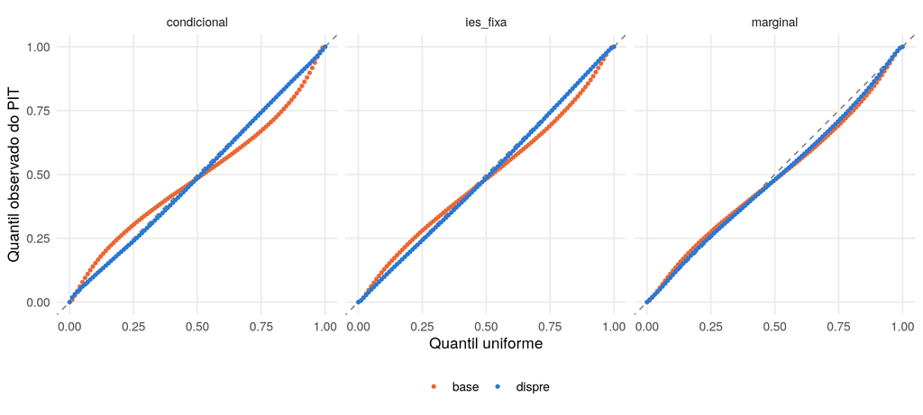

Figura 1: QQ-plot dos PIT contra a uniforme (100 quantis), por contexto.

```r
qq <- rbindlist(lapply(c("base", "dispre"), function(v) {
  p <- get(paste0("diag_", v))$pit
  rbindlist(lapply(names(p), function(k) { u <- sort(p[[k]]); ix <- round(seq(1, length(u), length.out = 100))
    data.table(modelo = v, contexto = k, teorico = ppoints(length(u))[ix], observado = u[ix]) }))
}))
ggplot(qq, aes(teorico, observado, colour = modelo)) + geom_abline(linetype = 2, colour = "grey50") + geom_point(size = 1) +
  facet_wrap(~contexto) + coord_equal() + scale_colour_manual(values = c(base = LARANJA, dispre = AZUL), name = NULL) +
  labs(x = "Quantil uniforme", y = "Quantil observado do PIT") + theme(legend.position = "bottom")
```

**Mostrar código**

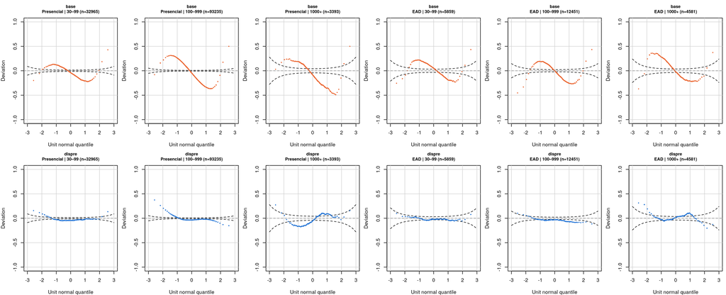

Figura 2: Worm-plots por modalidade e porte (contexto condicional): base (linha de cima) e dispre (linha de baixo). Bandas de 95% de gamlss::wp.

```r
porte <- cut(d$vinculos, c(0, 99, 999, Inf), labels = c("30–99", "100–999", "1000+"))
grupos <- CJ(modalidade = c("Presencial", "EAD"), porte = levels(porte), sorted = FALSE)
probs <- seq(.005, .995, length.out = 100)
par(mfrow = c(2, nrow(grupos)), mar = c(4, 4, 3, .6))
for (v in c("base", "dispre")) for (g in seq_len(nrow(grupos))) {
  u <- get(paste0("diag_", v))$pit$condicional[d$modalidade == grupos$modalidade[g] & porte == grupos$porte[g]]
  z <- qnorm(pmin(1 - 1e-12, pmax(1e-12, u)))
  withCallingHandlers(invisible(gamlss::wp(resid = z, pch = NA_integer_, bg = NA, line = TRUE, col = NA, xlim.all = 3, ylim.all = 1)),
    warning = function(w) if (grepl("Some points are missed out", conditionMessage(w), fixed = TRUE)) invokeRestart("muffleWarning"))
  q <- qnorm(probs); points(q, quantile(z, probs, type = 8) - q, pch = 16, cex = .5, col = if (v == "base") LARANJA else AZUL)
  abline(h = 0, lty = 2, col = "grey55"); title(main = sprintf("%s\n%s | %s (n=%s)", v, grupos$modalidade[g], grupos$porte[g], length(u)), cex.main = .85)
}
```

**Leitura.**

- O modelo anterior previa cerca de **metade dos cursos sem nenhuma saída**; o `dispre` chega perto dos zeros observados.
- Os PIT condicionais ficam praticamente uniformes, e o S dos worm-plots desaparece na maioria dos grupos.
- **O que continua imperfeito:** cursos com 1.000 ou mais vínculos e o nível marginal, que ignora os efeitos específicos de cada curso.

# 5 Hessiana, estabilidade e intervalos de confiança

Para que os erros-padrão façam sentido, o otimizador precisa ter chegado de fato ao máximo. Por isso o notebook:

1. calcula a Hessiana dos parâmetros populacionais por diferenças finitas do gradiente de Laplace;
2. dá um passo de Newton;
3. confere que o gradiente ficou próximo de zero;
4. obtém intervalos de Wald.

A Hessiana e o passo de Newton foram calculados logo após o ajuste (bloco `polimento`), para que todos os resultados usem o mesmo ponto final:

**Mostrar código**

```r
tab(data.table(Verificação = c("Maior |gradiente| antes do passo de Newton", "Maior |gradiente| depois",
                               "Menor autovalor da Hessiana (positivo = máximo bem definido)", "Variação do objetivo no passo"),
               Valor = c(br(max(abs(inf$gradiente$antes)), 2), br(max(abs(inf$gradiente$newton)), 3),
                         br(min(inf$autovalores), 2), formatC(diff(inf$objetivo), format = "e", digits = 1))))
```

| Verificação | Valor |
| --- | --- |
| Maior \|gradiente\| antes do passo de Newton | 39,01 |
| Maior \|gradiente\| depois | 0,020 |
| Menor autovalor da Hessiana (positivo = máximo bem definido) | 7,25 |
| Variação do objetivo no passo | -2.2e-02 |

**Mostrar código**

```r
nomes <- names(inf$par_newton); termos <- nomes
termos[nomes == "beta"] <- m_dispre$colnames$X; termos[nomes == "betadisp"] <- paste0("disp:", m_dispre$colnames$Z)
termos[nomes == "theta"] <- c("logDP_media_IES", "logDP_media_curso", "logDP_disp_IES", "logDP_disp_curso")
ep <- sqrt(pmax(diag(inf$V), 0))
cf <- data.table(termo = termos, est = inf$par_newton, ep = ep)[, `:=`(rc = exp(est), inf = exp(est - 1.96 * ep), sup = exp(est + 1.96 * ep))]
fwrite(cf, file.path(VAR, "dispre/inferencia/tabelas/coeficientes_notebook.csv"))
p_media <- sum(d$eventos_resposta) / sum(d$vinculos); esc <- 100 * p_media * (1 - p_media)   # pp por unidade de logit
rotulo <- c(p_25_anos_ou_mais = "25 anos ou mais", p_ppi = "Pretos, pardos e indígenas", p_escola_publica = "Egressos de escola pública",
            p_noturno = "No turno noturno", p_deficiencia = "Com deficiência (+1 pp)", p_reserva_vagas = "Ingresso por reserva de vagas",
            p_feminino = "Mulheres")
pf <- cf[termo %in% names(rotulo)][, `:=`(perfil = rotulo[termo], pp = esc * est, pp_inf = esc * (est - 1.96 * ep), pp_sup = esc * (est + 1.96 * ep))]
setorder(pf, -est)
tab(pf[, .(`Perfil (+10 pp no curso)` = perfil, `Razão de chances` = br(rc, 3), `IC 95%` = paste0(br(inf, 3), "–", br(sup, 3)),
           `≈ pp na taxa` = paste0(ifelse(pp > 0, "+", ""), br(pp, 2)))], align = "lrrr")
```

| Perfil (+10 pp no curso) | Razão de chances | IC 95% | ≈ pp na taxa |
| --- | --- | --- | --- |
| 25 anos ou mais | 1,029 | 1,026–1,032 | +0,63 |
| Pretos, pardos e indígenas | 1,024 | 1,020–1,027 | +0,51 |
| Egressos de escola pública | 1,018 | 1,016–1,021 | +0,40 |
| No turno noturno | 1,012 | 1,011–1,014 | +0,27 |
| Com deficiência (+1 pp) | 0,994 | 0,992–0,996 | -0,13 |
| Ingresso por reserva de vagas | 0,985 | 0,981–0,990 | -0,32 |
| Mulheres | 0,976 | 0,974–0,978 | -0,52 |

**Mostrar código**

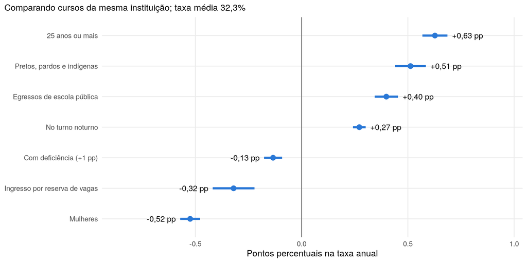

Figura 3: Variação aproximada da taxa anual para +10 pp de cada perfil, com IC 95%.

```r
pf[, perfil := factor(perfil, levels = perfil[order(pp)])]
ggplot(pf, aes(pp, perfil)) + geom_vline(xintercept = 0, colour = "grey40") +
  geom_errorbarh(aes(xmin = pp_inf, xmax = pp_sup), height = 0, colour = AZUL, linewidth = 1.4) + geom_point(colour = AZUL, size = 3) +
  geom_text(aes(x = ifelse(pp > 0, pp_sup, pp_inf), label = paste0(ifelse(pp > 0, "+", ""), br(pp, 2), " pp"),
                hjust = ifelse(pp > 0, -.15, 1.15)), size = 3.8) +
  scale_x_continuous(limits = c(-.85, .95)) + labs(x = "Pontos percentuais na taxa anual", y = NULL,
  subtitle = paste0("Comparando cursos da mesma instituição; taxa média ", pct(p_media)))
```

**Como ler.**

- A **razão de chances** compara as chances de desvínculo ou trancamento quando o perfil aumenta 10 pp no curso, mantendo constantes as demais variáveis, a instituição e o próprio curso.
- A coluna em pp é uma aproximação local, válida na taxa média.
- Perfis mais velhos, PPI, de escola pública e do noturno se associam a taxas maiores; mulheres e reserva de vagas, a taxas menores.
- Com 150 mil observações, quase tudo é estatisticamente significativo. O **tamanho** dos efeitos importa mais que os valores-p.

**Mostrar código**

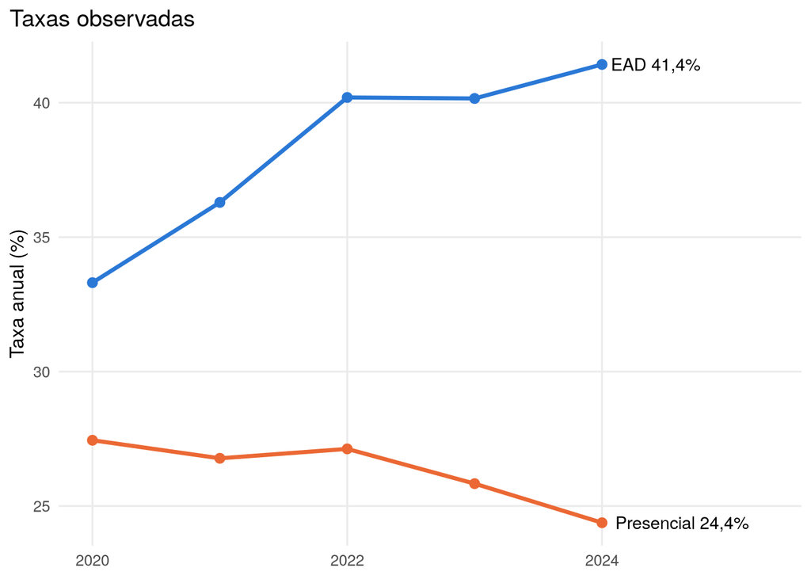

Figura 4: Esquerda: taxas observadas por modalidade. Direita: razão de chances da interação ano × EAD no modelo (2020 = 1).

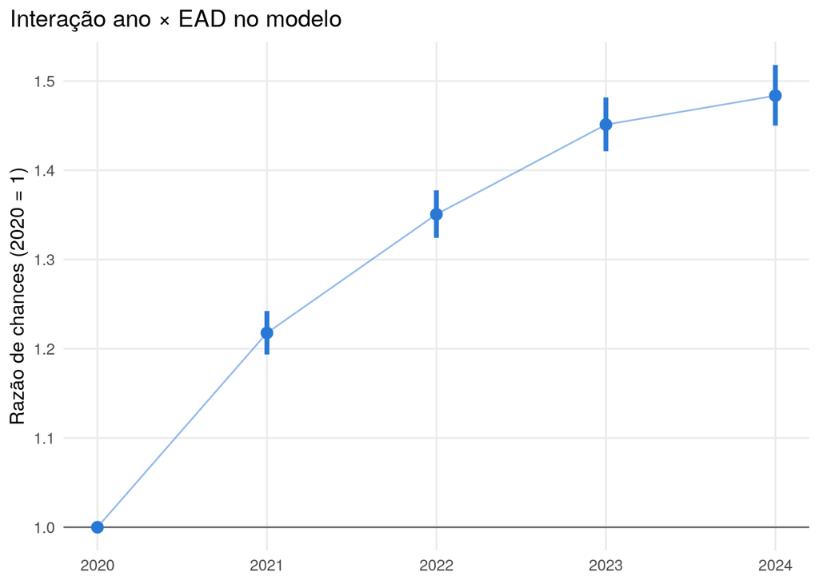

Figura 5: Esquerda: taxas observadas por modalidade. Direita: razão de chances da interação ano × EAD no modelo (2020 = 1).

```r
ev <- d[, .(taxa = sum(eventos_resposta) / sum(vinculos)), by = .(ano = as.integer(as.character(ano)), modalidade)]
print(ggplot(ev, aes(ano, 100 * taxa, colour = modalidade)) + geom_line(linewidth = 1.2) + geom_point(size = 2.5) +
  geom_text(data = ev[ano == 2024], aes(label = paste0(modalidade, " ", br(100 * taxa), "%")), hjust = -.1, colour = "black", size = 3.8) +
  scale_colour_manual(values = c(EAD = AZUL, Presencial = LARANJA), guide = "none") + scale_x_continuous(limits = c(2020, 2025.3)) +
  labs(x = NULL, y = "Taxa anual (%)", title = "Taxas observadas"))
ai <- rbind(data.table(ano = 2020L, rc = 1, inf = NA_real_, sup = NA_real_),
            cf[grepl("^ano20..:modalidadeEAD$", termo), .(ano = as.integer(substr(termo, 4, 7)), rc, inf, sup)])
print(ggplot(ai, aes(ano, rc)) + geom_hline(yintercept = 1, colour = "grey40") +
  geom_errorbar(aes(ymin = inf, ymax = sup), width = 0, colour = AZUL, linewidth = 1.4, na.rm = TRUE) +
  geom_line(colour = AZUL, alpha = .5) + geom_point(colour = AZUL, size = 3) +
  labs(x = NULL, y = "Razão de chances (2020 = 1)", title = "Interação ano × EAD no modelo"))
```

## 5.1 Como comparar EAD e presencial

O coeficiente `modalidadeEAD` isolado **não** é a comparação EAD × presencial. Como há interações com o ano e com o porte, ele vale só para 2020 e para N = 1, um curso que não existe nesta população. A comparação real soma os três termos, e o intervalo usa a matriz de covariância completa:

$$\log \text{RC}_{\text{EAD/presencial}}(\text{ano}, N) = \beta_{\text{EAD}} + \beta_{\text{ano}\times\text{EAD}} + \beta_{\text{EAD}\times\log N}\cdot\log N.$$

**Mostrar código**

```r
ib <- which(names(inf$par_newton) == "beta"); pb <- setNames(inf$par_newton[ib], m_dispre$colnames$X)
Vb <- inf$V[ib, ib]; dimnames(Vb) <- list(names(pb), names(pb))
contraste <- function(ano, N) {
  w <- setNames(numeric(length(pb)), names(pb)); w["modalidadeEAD"] <- 1; w["modalidadeEAD:log(vinculos)"] <- log(N)
  if (ano > 2020) w[paste0("ano", ano, ":modalidadeEAD")] <- 1
  e <- sum(w * pb); s <- sqrt(drop(t(w) %*% Vb %*% w))
  data.table(ano = ano, N = N, rc = exp(e), lo = exp(e - 1.96 * s), hi = exp(e + 1.96 * s))
}
ct <- rbindlist(lapply(c(50, 150, 500, 2000), function(N) rbindlist(lapply(2020:2024, contraste, N = N))))
ct[, txt := paste0(br(rc, 2), " (", br(lo, 2), "–", br(hi, 2), ")")]
ctw <- dcast(ct, N ~ ano, value.var = "txt"); setnames(ctw, "N", "Vínculos do curso")
tab(ctw, caption = "Razão de chances EAD/presencial (IC 95%), cursos comparáveis", align = "lrrrrr")
```

Razão de chances EAD/presencial (IC 95%), cursos comparáveis

| Vínculos do curso | 2020 | 2021 | 2022 | 2023 | 2024 |
| --- | --- | --- | --- | --- | --- |
| 50 | 0,86 (0,83–0,89) | 1,05 (1,02–1,08) | 1,16 (1,13–1,19) | 1,25 (1,21–1,28) | 1,28 (1,24–1,31) |
| 150 | 0,95 (0,92–0,97) | 1,15 (1,12–1,18) | 1,28 (1,25–1,31) | 1,37 (1,34–1,41) | 1,40 (1,37–1,44) |
| 500 | 1,05 (1,02–1,08) | 1,28 (1,25–1,31) | 1,42 (1,39–1,45) | 1,52 (1,49–1,56) | 1,56 (1,52–1,60) |
| 2.000 | 1,19 (1,15–1,22) | 1,44 (1,40–1,49) | 1,60 (1,55–1,65) | 1,72 (1,67–1,77) | 1,76 (1,71–1,81) |

**Mostrar código**

```r
e150 <- ct[N == 150]
```

**Leitura.**

- Num curso de porte típico (150 vínculos; mediana 182), EAD e presencial comparáveis eram parecidos em 2020: RC 0,95.
- Em 2024 a razão chega a **1,40**: chances cerca de 40% maiores no EAD. Para um presencial com taxa de 25%, isso equivale a cerca de 32% no EAD.
- A distância cresce com o porte do curso.
- A figura acima (direita) mostra só a **mudança desde 2020**, e não o nível da diferença.

# 6 Os achados da exploração têm base inferencial?

A exploração (notebook 01) comparava grupos sem controles. Abaixo, cada achado é confrontado com o que o modelo estima ao comparar cursos semelhantes da mesma instituição.

**Mostrar código**

```r
# Diferença bruta noturno − diurno dentro da IES (mesma definição do notebook 01)
p24 <- d[ano == 2024 & modalidade == "Presencial"]
p24[, turno := fifelse(p_noturno * SCALE["p_noturno"] >= .7, "Noturno", fifelse(p_noturno * SCALE["p_noturno"] <= .3, "Diurno", NA_character_))]
tx <- dcast(p24[!is.na(turno), .(t = sum(eventos_resposta) / sum(vinculos)), by = .(co_ies, turno)], co_ies ~ turno, value.var = "t")[!is.na(Noturno) & !is.na(Diurno)]
bruto_nt <- median(100 * (tx$Noturno - tx$Diurno))
co <- function(t, dg = 2) cf[termo == t, paste0(br(rc, dg), " (", br(inf, dg), "–", br(sup, dg), ")")]
nt <- cf[termo == "p_noturno"]
nt_pp <- 10 * esc * nt$est; nt_inf <- 10 * esc * (nt$est - 1.96 * nt$ep); nt_sup <- 10 * esc * (nt$est + 1.96 * nt$ep)
tab(data.table(
  `Achado da exploração (sem controles)` = c(paste0("Noturno − diurno na mesma IES: +", br(bruto_nt), " pp (", nrow(tx), " IES)"),
    "Mais egressos de escola pública, taxa maior", "EAD se afasta do presencial", "Rede pública abaixo da privada",
    "Saúde e Agricultura baixas; TIC e Serviços altas (composta)", "ProUni: gradiente só no desvínculo"),
  `Modelo (IC 95%)` = c(paste0("Curso 100% × 0% noturno: +", br(nt_pp), " pp (", br(nt_inf), " a ", br(nt_sup), ")"),
    paste0("RC ", co("p_escola_publica", 3), " por +10 pp"),
    paste0("EAD/presencial (150 vínculos): ", br(e150[ano == 2020]$rc, 2), " em 2020 → ", e150[ano == 2024]$txt, " em 2024"),
    paste0("Federal ", co("categoria_administrativaPública Federal"), "; estadual ", co("categoria_administrativaPública Estadual")),
    paste0("Saúde ", co("cine_area_geral09"), "; Agricultura ", co("cine_area_geral08"), "; TIC ", co("cine_area_geral06"), "; Serviços ", co("cine_area_geral10"), " (contra Negócios)"),
    "Não incluído no modelo"),
  `Base inferencial` = c("Sim; o efeito cai à metade com os controles", "Sim; efeito pequeno", "Sim; forte", "Sim",
                         "Em parte; Saúde segue baixa, TIC cai abaixo de Negócios", "Não")), align = "lll")
```

| Achado da exploração (sem controles) | Modelo (IC 95%) | Base inferencial |
| --- | --- | --- |
| Noturno − diurno na mesma IES: +5,5 pp (589 IES) | Curso 100% × 0% noturno: +2,7 pp (2,4 a 3,0) | Sim; o efeito cai à metade com os controles |
| Mais egressos de escola pública, taxa maior | RC 1,018 (1,016–1,021) por +10 pp | Sim; efeito pequeno |
| EAD se afasta do presencial | EAD/presencial (150 vínculos): 0,95 em 2020 → 1,40 (1,37–1,44) em 2024 | Sim; forte |
| Rede pública abaixo da privada | Federal 0,78 (0,64–0,95); estadual 0,86 (0,77–0,97) | Sim |
| Saúde e Agricultura baixas; TIC e Serviços altas (composta) | Saúde 0,78 (0,77–0,79); Agricultura 0,84 (0,82–0,86); TIC 0,91 (0,89–0,92); Serviços 1,06 (1,03–1,09) (contra Negócios) | Em parte; Saúde segue baixa, TIC cai abaixo de Negócios |
| ProUni: gradiente só no desvínculo | Não incluído no modelo | Não |

**Mostrar código**

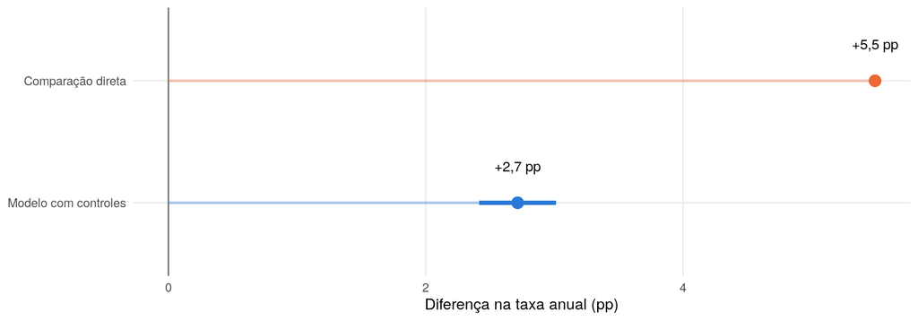

Figura 6: Noturno − diurno: comparação direta dentro das IES contra estimativa do modelo com controles (IC 95%).

```r
ggplot(data.table(o = factor(c("Comparação direta", "Modelo com controles"), levels = c("Modelo com controles", "Comparação direta")),
                  pp = c(bruto_nt, nt_pp), inf = c(NA, nt_inf), sup = c(NA, nt_sup)), aes(pp, o, colour = o)) +
  geom_vline(xintercept = 0, colour = "grey40") + geom_segment(aes(x = 0, xend = pp, yend = o), alpha = .35, linewidth = 1) +
  geom_errorbarh(aes(xmin = inf, xmax = sup), height = 0, linewidth = 1.6, na.rm = TRUE) + geom_point(size = 4) +
  geom_text(aes(label = paste0("+", br(pp), " pp")), nudge_y = .3, colour = "black") +
  scale_colour_manual(values = c("Comparação direta" = LARANJA, "Modelo com controles" = AZUL), guide = "none") +
  labs(x = "Diferença na taxa anual (pp)", y = NULL)
```

O modelo confirma o achado do noturno: um curso inteiramente noturno tem taxa **2,7 pp maior** que um diurno comparável da mesma instituição. A diferença bruta (5,5 pp) era maior porque parte dela vinha da idade e da origem escolar, que andam junto com o turno.

# 7 Validação em anos reservados (opcional)

**Mostrar código**

```r
# Reajusta no treino (um ano por curso fora), sorteia os efeitos latentes da normal conjunta
# de Laplace (200 sorteios) e avalia a previsão dos anos reservados por log-score e Pearson².
te <- which(d$validacao); y_te <- d$eventos_resposta[te]; N_te <- d$vinculos[te]
avaliar <- function(v, inicio) {
  m <- obter(v, "treino", inicio); tr <- which(!d$validacao); ds <- design(v, d)
  vm <- variant_map(v, nlevels(d$co_ies), nlevels(d$co_curso))
  dd <- list(X = ds$X[tr, ], Z = ds$Z[tr, ], y = d$eventos_resposta[tr], N = d$vinculos[tr], ies = as.integer(d$co_ies[tr]) - 1L,
             curso = as.integer(d$co_curso[tr]) - 1L, n_ies = nlevels(d$co_ies))
  o <- TMB::MakeADFun(dd, m$parameters, random = vm$random, map = vm$map, DLL = DISP_DLL, silent = TRUE); o$fn(o$par)
  Q <- Matrix::forceSymmetric(o$env$spHess(o$env$last.par, random = TRUE)); full <- o$env$last.par
  modo <- unname(full[o$env$random]); tipo <- names(full)[o$env$random]
  Fq <- Matrix::expand(Matrix::Cholesky(Q, LDL = FALSE, perm = TRUE)); TMB::FreeADFun(o); rm(o, Q); gc()
  ni <- nlevels(d$co_ies); ii <- as.integer(d$co_ies[te]); ci <- as.integer(d$co_curso[te])
  eta0 <- drop(ds$X[te, ] %*% m$parameters$beta); lphi0 <- drop(ds$Z[te, ] %*% m$parameters$betadisp)
  py <- m1 <- m2 <- numeric(length(te)); set.seed(SEED + 202L); S <- 200
  for (s in seq_len(S)) {
    x <- modo + as.vector(Matrix::crossprod(Fq$P, Matrix::solve(Matrix::t(Fq$L), rnorm(length(modo)))))
    b <- x[tipo == "b"]; bd <- m$parameters$bd; if (v != "base") bd[if (length(vm$map)) !is.na(vm$map$bd) else TRUE] <- x[tipo == "bd"]
    mu <- pmin(1 - 1e-10, pmax(1e-10, plogis(eta0 + b[ii] + b[ni + ci]))); phi <- exp(pmin(30, lphi0 + bd[ii] + bd[ni + ci]))
    mo <- trunc_moments(mu, phi, N_te)
    py <- py + trunc_density(y_te, N_te, mu, phi) / S; m1 <- m1 + mo$mean / S; m2 <- m2 + mo$second / S
  }
  data.table(Modelo = v, `Log-score médio` = br(mean(log(py)), 3), `Pearson²` = br(mean((y_te / N_te - m1)^2 / (m2 - m1^2)), 2),
             `Taxa prevista` = pct(sum(m1 * N_te) / sum(N_te), 2), `Taxa observada` = pct(sum(y_te) / sum(N_te), 2))
}
r_base <- avaliar("base", function(l) inicio_logistica("base", l))
r_disp <- avaliar("dispre", function(l) { p <- readRDS(variant_path("base", "treino", POP))$parameters; p$theta[3:4] <- log(.1); p })
tab(rbind(r_base, r_disp))
```

*Seção desligada nesta renderização (parâmetro reserva = false).* Esta validação separa um ano de cada curso (30.982 curso-anos), reajusta o modelo sem eles e mede a qualidade da previsão desses anos, levando em conta a incerteza dos efeitos de cada curso e instituição.

Nas execuções do projeto, o `dispre` teve log-score −4,17 contra −4,38 do `base`, com Pearson² de 1,20: previsões um pouco estreitas demais. A validação é **retrospectiva**, porque esses anos já orientaram a escolha entre variantes. Não é uma validação confirmatória.

# 8 Limitações

- **Associações ecológicas:** o perfil dos matriculados não identifica quem saiu, e os dados não são individuais.
- **Medida:** inclui trancamento, que pode ser temporário. Não é a evasão oficial do INEP.
- **População:** cursos estáveis com 30 vínculos ou mais. Os resultados não se estendem a cursos pequenos ou que fecharam.
- **Variáveis fora do modelo:** FIES (registro falho), ProUni, apoio social, qualidade e contexto territorial.
- **Ajuste:** persistem desvios em cursos com 1.000 ou mais vínculos e no nível marginal.
- **Inferência:** intervalos de Wald condicionais à aproximação de Laplace e à especificação. Não houve seleção de variáveis.